# API Client for ENGIE’s Open Wind Farm

2017-07-12

The wind farm called `La Haute Borne’ (ENGIE Group) is located in the Meuse department in France, and is made of four Senvion MM82 wind turbines commissioned in January, 15th, 2009.

```r
library(openwindfarm)
map_owf()
```

[interactive chart not shown]

The main function of the package ‘openwindfarm’ is `get_owf()`. It retrives Scada data from this wind farm, distributed by [the ENGIE Group](http://www.engie.com) under the terms of the [Open Licence 2.0](https://www.etalab.gouv.fr/wp-content/uploads/2017/04/ETALAB-Licence-Ouverte-v2.0.pdf), provided by [Etalab](https://www.etalab.gouv.fr/en/qui-sommes-nous) and designed to be compatible notably with the “Creative Commons Attribution 4.0” (CC-BY 4.0) license of Creative Commons.

The first argument of `get_owf()` is the name of the wind turbine to be considered, among the four wind turbines of the wind farm named `"R80711"` (or `1`), `"R80790"` (or `2`), `"R80721"` (or `3`), and `"R80736"` (or `4`).

```r
df <- get_owf(wind_turbine = "R80711",
              start_date = "2012-12-10 00:10:00",
              end_date = "2013-01-15 03:30:00")
```

In addition to the columns `Wind_turbine_name` and `Date_time`, the dataset is made of 136 columns, which record every 10 minutes the average, the minimum, the maximum, and the standard deviation over 10 minutes of 34 measurements related to the operational behavior of the 4 wind turbines. Among these measurements one may find e.g. the rotor speed `Rs`:

```r
library(dplyr)
df %>%
  select("Wind_turbine_name", "Date_time", starts_with("Rs")) %>%
  head()
```

```
#> # A tibble: 6 x 6
#>   Wind_turbine_name           Date_time Rs_avg Rs_min Rs_max Rs_std
#>               <chr>              <dttm>  <dbl>  <dbl>  <dbl>  <dbl>
#> 1            R80711 2012-12-10 00:10:00  17.10  15.88  17.48   0.25
#> 2            R80711 2012-12-10 00:20:00  17.11  16.44  17.36   0.17
#> 3            R80711 2012-12-10 00:30:00  16.93  15.53  17.30   0.42
#> 4            R80711 2012-12-10 00:40:00  16.07  12.44  17.28   1.28
#> 5            R80711 2012-12-10 00:50:00  16.17  13.43  17.34   1.18
#> 6            R80711 2012-12-10 01:00:00  15.71  11.16  17.45   1.89
```

The dataset describing these 34 measurements can be retrieved with the `get_info` function.

The following chart depicts the usual relation between the active power produced by a wind turbine and the cube of the wind speed measured by the nacelle anemometer:

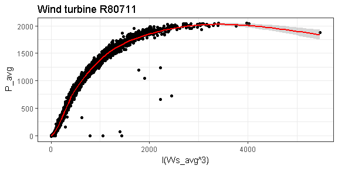

```r
library(ggplot2)
ggplot(df, aes(I(Ws_avg^3), P_avg)) +
  geom_point() +
  geom_smooth(colour = "red") +
  ggtitle("Wind turbine R80711") +
  theme_bw()
```